# Model Building Example

Matt Guan

December 11, 2016

# Business Context

Regression is a powerful tool that is used widely across industries. Businesses typically use regression to gain insights into the key drivers of their KPI of interest (Volume Sales, Revenue, Conversion Rate, Close Rate etc.)

The purpose of this exercise is to provide a very simple example of a log-log model, and to highlight some of the key steps in the model building process. In addition, we will cover how to translate our model coefficients into a tangible output that can be leveraged by the business.

# Useful R Packages

```r
library(data.table) #use SQL syntax in R
library(dplyr) #comprehensive data cleaning package
library(randomForest) #Random Forest ; Frequently used to test variable importance
library(ggplot2) #better graphics than base
library(lmtest) #lots of model diagnostic calculations
```

# Data Import / Cleaning

The below code imports 2 files - The SuperStore dataset, which is commonly used in Tableau Examples, and a returns mapping file. Data is at a transaction level

```r
getwd()
```

```
## [1] "C:/Users/Matt/Desktop/Modeling Example"
```

```r
setwd("C:/Users/Matt/Desktop/Modeling Example")
read.csv("Sales.csv", header=T, na.strings="", stringsAsFactors = T) -> sales
read.csv("Closed.csv", header=T, na.string="") -> close

merge(sales, close, by="Order.ID", all.x=T)->sales
sales$close_status <- ifelse(is.na(sales$Status), 0, 1)
```

In addition, there is usually some data cleaning involved in the initial steps. Here I need to convert the date metrics to the proper format

```r
#Generate Date Variables Dates
sales$order_date<-as.Date(sales$Order.Date, origin="1899-12-30")
sales$ship_date<-as.Date(sales$Ship.Date, origin="1899-12-30")
sales$ship_time<-difftime(sales$ship_date, sales$order_date, units="days")

sales$week<-ifelse(sales$Week..<10, paste("0",sales$Week..,sep=""), as.character(sales$Week..))
sales$month<-ifelse(sales$Month<10, paste("0",sales$Month,sep=""), as.character(sales$Month))
sales$fiscal_week<- paste(sales$Year,"-",sales$Week.., sep="")
```

# Quick Data Breakdown

First, I want to take a quick look into the data to see what level I can do my analysis at.

```r
data.frame(table(sales$Product.Name))->x
x<- x[order(-x$Freq),]
x[1:5,]
```

```
##                                                                  Var1 Freq
## 559                         Global High-Back Leather Tilter, Burgundy   24
## 259                                   Bevis 36 x 72 Conference Tables   22
## 291 BoxOffice By Design Rectangular and Half-Moon Meeting Room Tables   22
## 506                                        Fiskars® Softgrip Scissors   22
## 752                        Master Giant Foot® Doorstop, Safety Yellow   22
```

It looks like that at a product level, the maximum number of records is 24. Based on the small number of records, I would have to aggregate my models up to the sub-category level. This increase in records would come at the expense of an increase in the variance of the data, and most likely a less clear trend. Normal POS data is usually much more robust than this example set.

```r
options(width=100)
summary(sales$Product.Category)
```

```
##       Furniture Office Supplies      Technology
##            1724            4610            2065
```

```r
data.table(sales)->stage
stage[,.(Revenue = sum(Sales), mean.price=mean(Unit.Price), sd.price = sd(Unit.Price),
         mean.vol=mean(Order.Quantity), sd.vol=sd(Order.Quantity), .N),
     by=Product.Sub.Category]->table1
table1
```

```
##               Product.Sub.Category    Revenue mean.price    sd.price mean.vol   sd.vol    N
##  1:         Storage & Organization 1070182.60  79.898004   95.830918 25.28205 14.14152  546
##  2:  Scissors, Rulers and Trimmers   80996.31  42.371458  213.260886 27.29861 14.26869  144
##  3:           Computer Peripherals  795875.94  42.504261   49.239625 25.35884 13.98945  758
##  4:             Office Furnishings  698093.81  33.329708   40.016290 26.20305 14.91490  788
##  5:                         Tables 1896008.14 221.388089  126.807828 25.47091 14.69013  361
##  6:   Telephones and Communication 1889313.80  98.351268   58.739632 26.01246 14.50900  883
##  7:            Pens & Art Supplies  167107.22   9.617646   10.676717 26.82464 14.35752  633
##  8:                   Rubber Bands   15006.63   3.010894    1.549478 27.48603 14.67604  179
##  9:                         Labels   38981.55   5.506875   10.092762 25.35069 14.46798  288
## 10:                          Paper  446452.86  14.409788   15.392186 25.20082 14.18507 1225
## 11:                Office Machines 2168697.14 565.719496 1135.770083 23.31157 15.54681  337
## 12:                      Bookcases  822652.04 172.834921  188.466455 25.87831 13.93301  189
## 13: Binders and Binder Accessories 1022957.59  57.602383  180.444817 25.12787 14.32775  915
## 14:                     Appliances  736991.54  72.639816   92.779069 25.11751 14.58328  434
## 15:                      Envelopes  174085.80  26.202602   34.794605 26.73984 14.51886  246
## 16:             Chairs & Chairmats 1761836.55 183.137642  113.214142 24.84456 14.82545  386
## 17:                Copiers and Fax 1130361.30 745.967011  831.719233 24.45977 16.07671   87
```

```r
#For the sake of simplicity, we are doing a subcategory analysis for paper
subset(sales, Product.Sub.Category == "Paper")->set
set<- set[order(set$Year, set$Week..),]
set$ID<- 1:nrow(set)

#Variables of Interest - Holiday, Order Priority, Order Qty, Discount, Ship Mode,
#Shipping Cost / Unit Price, Customer Segment, shipping time
data.table(set)->set
set[,.(ID, Year, month, week, Sales, Product.Name, fiscal_week, order_date,
       Order.Priority, Order.Quantity, Unit.Price,
       Discount, Ship.Mode, Shipping.Cost,
       Customer.Segment,
       ship_time, close_status)] ->reg
```

# Step 1: Data Cleaning

In 9 out of 10 cases, your data will not be in a proper format for conducting analysis. Most times, there will be a significant amount of data cleaning involved. Some of the typical steps in this process are listed below.

- Outlier Treatment
- Duplicate Value Treatment
- Missing Value Treatment
- Aggregate data
- Secondary Variable Generation
- Data Mapping from various sources

In this example, we will be mapping on Holidays from another file, changing the level of data, generating a secondary variable, and performing oulier treatment

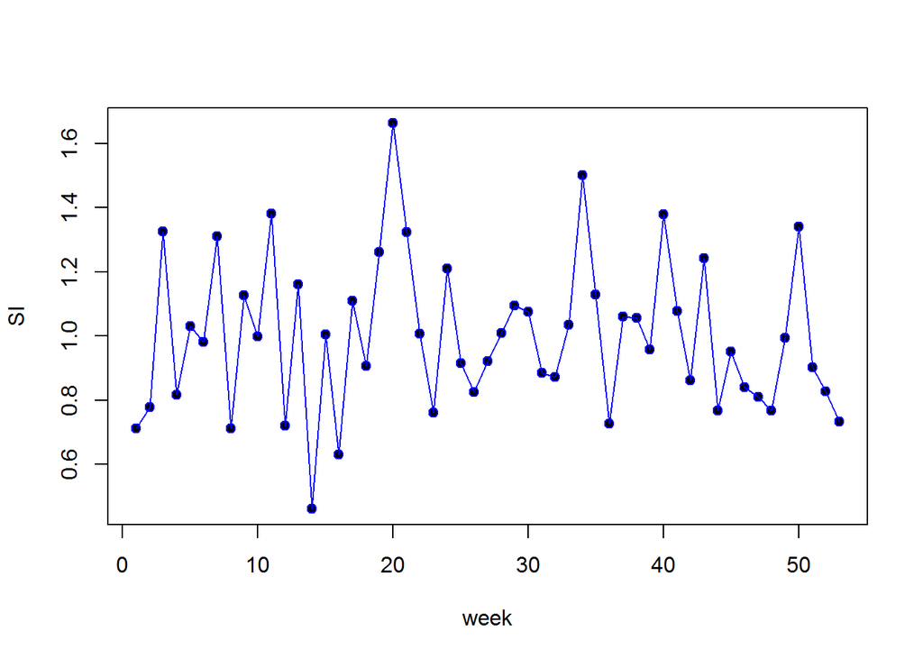

```r
#Join Holidays from mapping file
read.csv("Holiday_Mapping.csv")->holidays
holidays$week<-ifelse(holidays$week<10, paste("0",holidays$week,sep=""), as.character(holidays$week))
merge(reg, holidays, all.x=T)->reg

#Aggregate Data up to fiscal-week level
data.table(reg)->reg
reg[,.(Unit_Sales=sum(Order.Quantity), Price=mean(Unit.Price), Discount=mean(Discount), Holiday_Flag), by=.(Year,week)]->reg1
unique(reg1)->reg1
reg1<- reg1[order(reg1$Year, reg1$week),]
reg1$fiscal_week<-paste(reg1$Year,"-",reg1$week, sep="")


#Generate a "Seasonality Index" Variable to capture the seasonal fluctuation of our dependent variable
reg1[,overall_mean_sales := mean(Unit_Sales)]->reg1
reg1[,SI := mean(Unit_Sales)/overall_mean_sales, by=c("week")]->reg1

#Example Plot of the SI variable
unique(reg1[,c("week", "SI")])->SI
plot(SI~week, data=SI, pch=19, lty=1)
lines(SI~week, data=SI, type = "o", col = "blue")
```

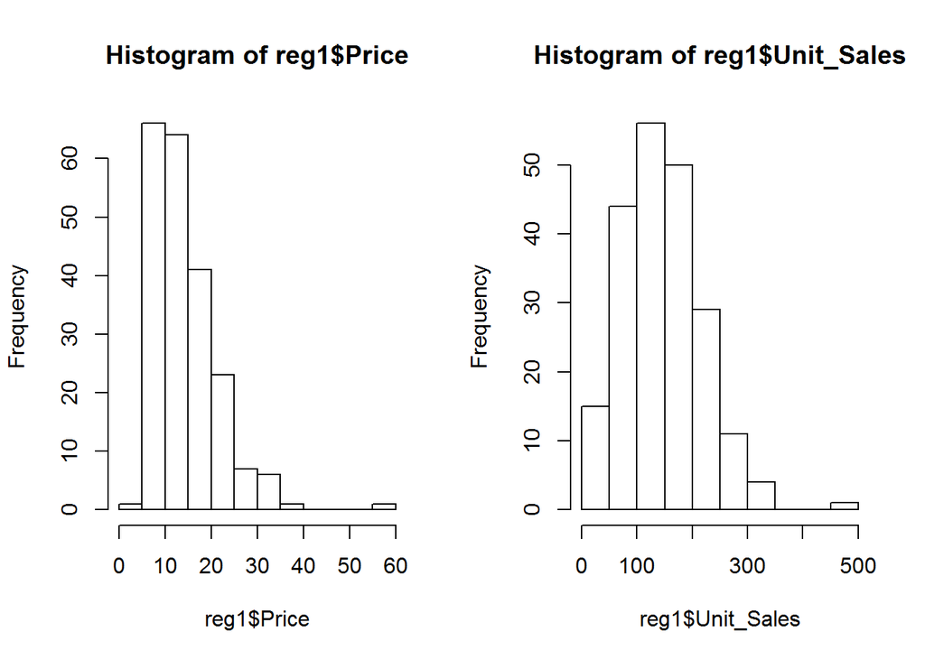

```r
#Outlier Treatment
unname(quantile(reg1$Price, .99))->x
unname(quantile(reg1$Unit_Sales, .99))->y

par(mfrow=c(1,2))
hist(reg1$Price)
hist(reg1$Unit_Sales)
```

```r
reg1$outlier_flag<-ifelse(reg1$Price>x, 1,
                          ifelse(reg1$Unit_Sales>y, 1,
                          ifelse(reg1$Unit_Sales<10,1, 0)))

subset(reg1, outlier_flag==0)->reg_1
```

# Step 2: Exploratory Data Analysis

Before any modeling can done, there is typically a very thorough exploratory data analysis to explore trends in the data, and data quality. This gives a general idea of what models may be a good fit, and what some potential issues may be. For the sake of brevity, many parts of this portion of the analysis has been greatly simplified

First, we will look again at the distribution of our key continuous variables. Looking at the below graphs, we can now see that the distributions for price, and volume are now much more normal, post-outlier treatment.

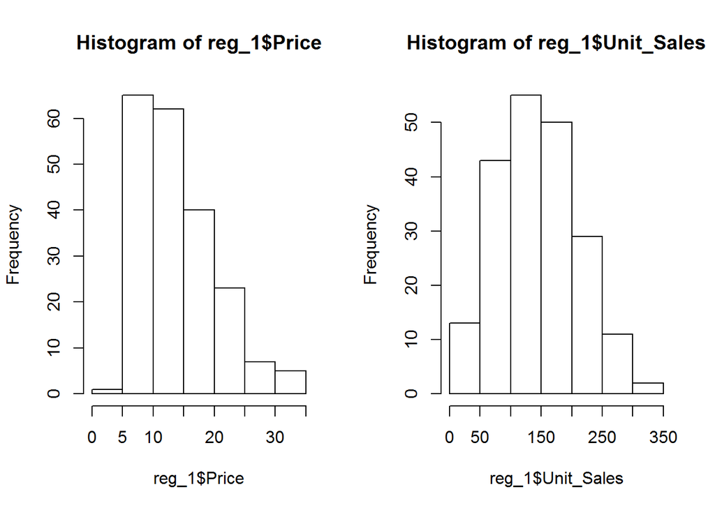

```r
options(width=100)

par(mfrow=c(1,2))
hist(reg_1$Price)
hist(reg_1$Unit_Sales)
```

Next, we will do a quick univariate analysis on price, which we are assuming to be one of the key drivers of volume sales. In a full analysis, we would perform an independent investigation on each variable, prior to modeling. Here, we are testing to see if price and volume follow a linear, or log-log relationship.

When you look at these two graphs, you may notice that the r^2 are extremely low, indicating that price itself may not be the best fit. Typically, we would be looking for an r^2, that is a little higher, especially if we are expecting it to be the primary driver of our dependent variable. However, in multiple regression, a low r^2 is not the end of the world, as other variables may have more explanatory power than we expect.

The log-log model has a slightly better fit than the linear model, so this is the model we will move forward with. Typically in a business context, the log-log model works very well. The reason for the lack of fit in this case is most likely due to the aggregation performed earlier. If this was a real business problem though, we would probably consider a variety of all models, or hold off on the analysis until a more robust data-set at a product level was obtained.

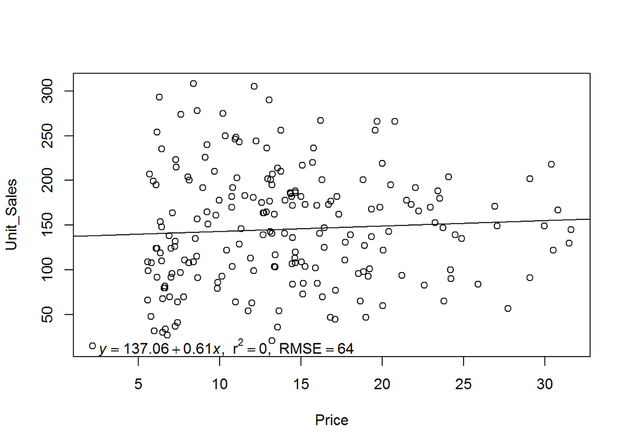

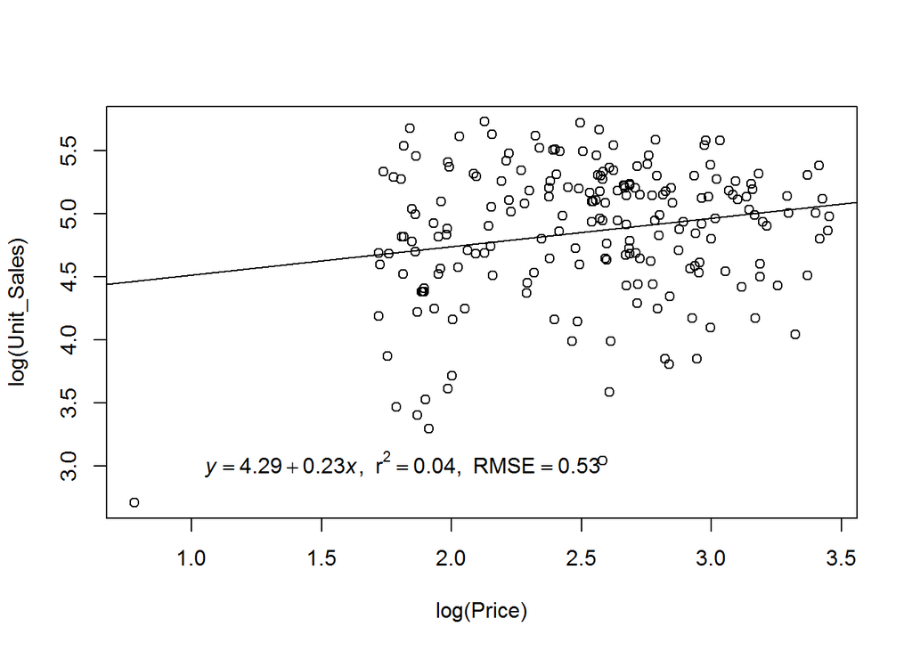

Lastly, we will do a check for multicollinearity between the potential model coefficients. Ideally, the variables should be independent, so that each beta coefficient can capture the isolated effect of the variable in question.

Looking at the correlation matrix below, we can see that there is no noticeable correlation between our independent variables.

```
## Computing correlation using spearman-method with listwise-deletion...
```

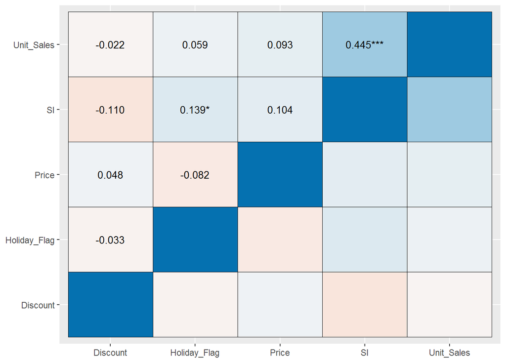

```r
#Correlation Matrix
data.frame(reg_1)->cm
cm[,c(3:6,9)]->cm
library(sjPlot)
lapply(cm, as.numeric)->cm[]
sjp.corr(cm)
```

# Step 3: Model Fitting

The next step of the process would be to actually fit, and evaluate the potential models. The below function is used to calculate some of the typical metrics that are used for model comparison.

The metrics listed here are as follows

- R^2 - to evaluate the fit of the model / how much of the variance is explained by our variables
- Adjusted RSQ - to evalulate the fit of the model, normalizing for the # of variables present
- P Statistic - to evaluate the significance of our variables
- MSE - a metric that allows us to evalulate the residuals
- MAPE - average error in our model
- AIC - a variable that would allow for easy model comparison

```r
mdiagnostics<-function(x){
diagnostics<-summary(x)
model<-data.frame(RSQ=diagnostics$r.squared)
model$fstat<-diagnostics$fstatistic[1]
model$pstat<-pf(diagnostics$fstatistic[1], diagnostics$fstatistic[2], diagnostics$fstatistic[3], lower.tail=F)
model$MSE<-mean(diagnostics$residuals^2)
model$AdjRSQ<-diagnostics$adj.r.squared
model$AIC<-AIC(x)
model$MAPE<- lapply((abs(diagnostics$residuals/x$model[1])), mean, na.rm=T)
#Check for Heteroscedasticity
model$BPTestBP<-bptest(x)$statistic
model$BPTestDF<-bptest(x)$parameter
model$BPTestPValue<-bptest(x)$p.value
return(model)
}
```

In this example, we will look at 2 models - a linear and a log-log model. The model formulas are below.
$$m1: Sales = Price + DiscountFlag + SIndex + HolidayFlag$$

$$m2: log(Sales) = log(Price) + DiscountFlag + SIndex +HolidayFlag$$

```r
#Model Runs
m1 <- lm(Unit_Sales~Price+Discount+SI+Holiday_Flag, data=reg_1)
m2 <- lm(log(Unit_Sales)~log(Price)+Discount+log(SI)+Holiday_Flag, data=reg_1)
```

```r
#model diagnostics for model 1 (linear)
summary(m1)
```

```
##
## Call:
## lm(formula = Unit_Sales ~ Price + Discount + SI + Holiday_Flag,
##     data = reg_1)
##
## Residuals:
##      Min       1Q   Median       3Q      Max
## -126.290  -44.525   -4.858   39.074  157.834
##
## Coefficients:
##               Estimate Std. Error t value Pr(>|t|)
## (Intercept)    26.8490    24.3507   1.103    0.272
## Price           0.2264     0.6418   0.353    0.725
## Discount     -156.3744   270.9211  -0.577    0.564
## SI            123.5944    18.0423   6.850 9.09e-11 ***
## Holiday_Flag   -0.7655     9.9449  -0.077    0.939
## ---
## Signif. codes:  0 '***' 0.001 '**' 0.01 '*' 0.05 '.' 0.1 ' ' 1
##
## Residual standard error: 57.93 on 198 degrees of freedom
## Multiple R-squared:  0.204,  Adjusted R-squared:  0.1879
## F-statistic: 12.68 on 4 and 198 DF,  p-value: 3.304e-09
```

```r
mdiagnostics(m1)
```

```
##         RSQ    fstat        pstat      MSE    AdjRSQ      AIC     MAPE BPTestBP BPTestDF
## 1 0.2039544 12.68237 3.303837e-09 3272.949 0.1878727 2231.059 0.494716 13.46738        4
##   BPTestPValue
## 1  0.009204112
```

```r
#model diagnostics for model 2 (log-log)
summary(m2)
```

```
##
## Call:
## lm(formula = log(Unit_Sales) ~ log(Price) + Discount + log(SI) +
##     Holiday_Flag, data = reg_1)
##
## Residuals:
##      Min       1Q   Median       3Q      Max
## -1.75569 -0.27185  0.07778  0.34040  1.05599
##
## Coefficients:
##              Estimate Std. Error t value Pr(>|t|)
## (Intercept)   4.64413    0.21620  21.481  < 2e-16 ***
## log(Price)    0.17071    0.07153   2.387   0.0179 *
## Discount     -3.55322    2.22612  -1.596   0.1121
## log(SI)       0.96597    0.14522   6.652 2.76e-10 ***
## Holiday_Flag -0.05358    0.08167  -0.656   0.5125
## ---
## Signif. codes:  0 '***' 0.001 '**' 0.01 '*' 0.05 '.' 0.1 ' ' 1
##
## Residual standard error: 0.4768 on 198 degrees of freedom
## Multiple R-squared:  0.229,  Adjusted R-squared:  0.2134
## F-statistic:  14.7 on 4 and 198 DF,  p-value: 1.564e-10
```

```r
mdiagnostics(m2)
```

```
##         RSQ    fstat        pstat       MSE   AdjRSQ      AIC       MAPE BPTestBP BPTestDF
## 1 0.2289703 14.69986 1.563869e-10 0.2217678 0.213394 282.3458 0.08182225 19.64697        4
##   BPTestPValue
## 1  0.000586249
```

Looking at the summary statistics, it can be noted that the variables are showing much higher levels of significance in the log-log model. The insignificant variables (p>0.05) are holiday, and discount. In addition, the AIC and MAPE are both **greatly** reduced with the log-log model (AIC down from 2231 to 282 ; MAPE down from 50% to 8%)

Next let’s remove the insignificant holiday variable.

```r
#final model : log-log with the holiday variable removed
m3 <- lm(log(Unit_Sales)~log(Price)+Discount+log(SI), data=reg_1)
summary(m3)
```

```
##
## Call:
## lm(formula = log(Unit_Sales) ~ log(Price) + Discount + log(SI),
##     data = reg_1)
##
## Residuals:
##      Min       1Q   Median       3Q      Max
## -1.74357 -0.26045  0.07368  0.34688  1.01351
##
## Coefficients:
##             Estimate Std. Error t value Pr(>|t|)
## (Intercept)  4.61775    0.21213  21.769  < 2e-16 ***
## log(Price)   0.17625    0.07092   2.485   0.0138 *
## Discount    -3.55835    2.22292  -1.601   0.1110
## log(SI)      0.94878    0.14263   6.652 2.73e-10 ***
## ---
## Signif. codes:  0 '***' 0.001 '**' 0.01 '*' 0.05 '.' 0.1 ' ' 1
##
## Residual standard error: 0.4761 on 199 degrees of freedom
## Multiple R-squared:  0.2273, Adjusted R-squared:  0.2156
## F-statistic: 19.51 on 3 and 199 DF,  p-value: 3.944e-11
```

```r
mdiagnostics(m3)
```

```
##        RSQ    fstat        pstat     MSE    AdjRSQ      AIC       MAPE BPTestBP BPTestDF
## 1 0.227294 19.51216 3.943512e-11 0.22225 0.2156451 280.7867 0.08229015 17.14685        3
##   BPTestPValue
## 1 0.0006592559
```

First, let’s quickly look at some residual plots to ensure that there is no trend in the errors

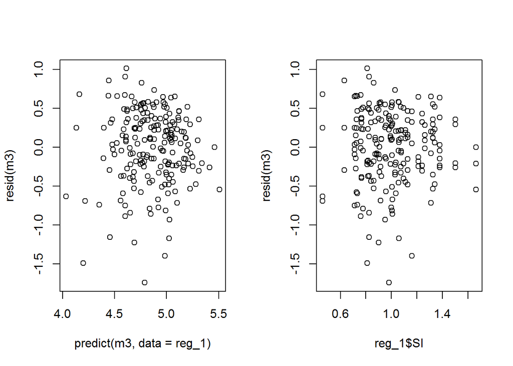

```r
par(mfrow=c(1,2))
plot(predict(m3, data=reg_1),resid(m3))
plot(reg_1$SI,resid(m3))
```

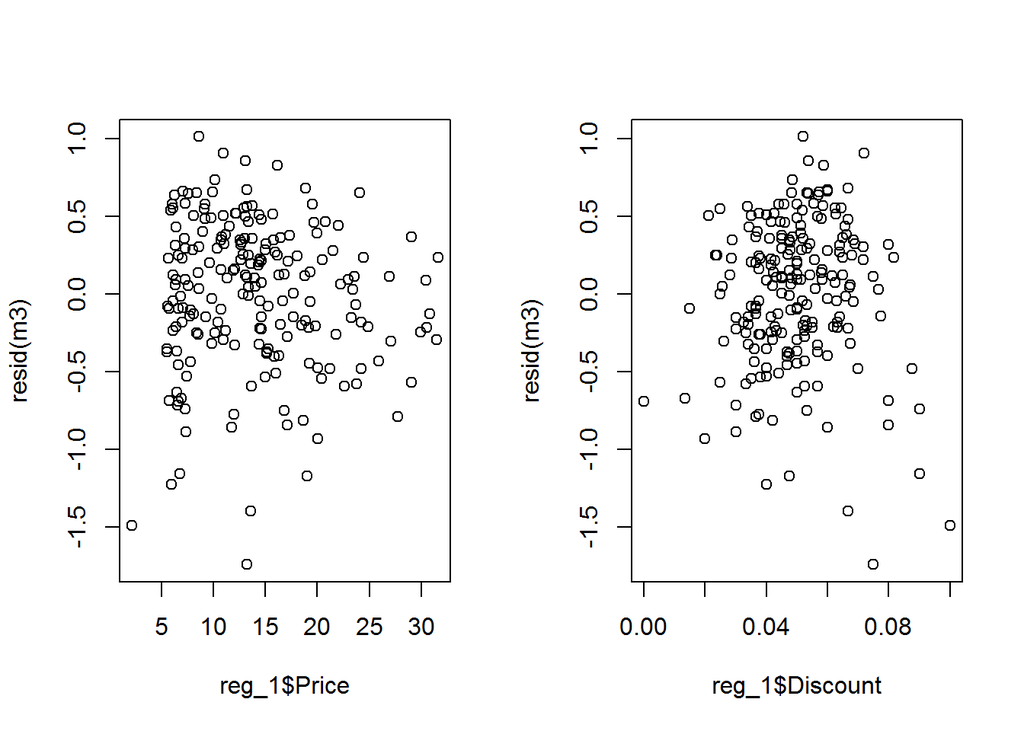

```r
plot(reg_1$Price, resid(m3))
plot(reg_1$Discount, resid(m3))
```

The residuals look pretty random to me, which is good.

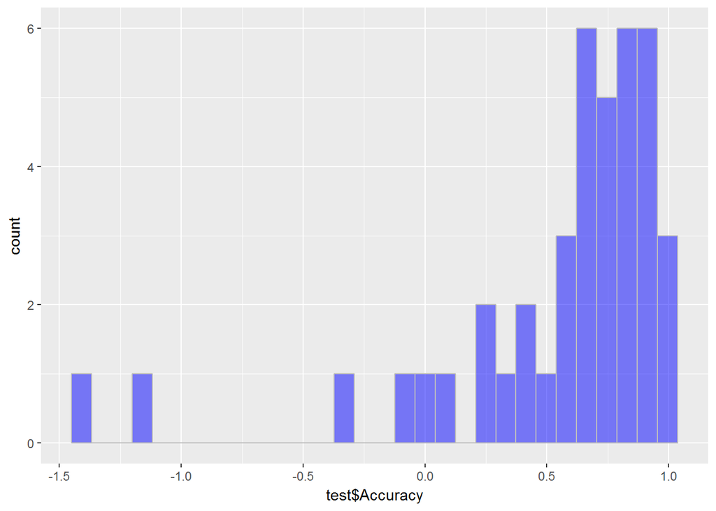

```r
#Accuracy Chart Generation

#Train / Test
floor(0.8 * nrow(reg_1))->train_len
train_len+1->test_start
reg_1[1:train_len,]->train
reg_1[test_start:nrow(reg1),]->test


#test/train accuracy
test$prediction<- predict(m3,test)
test$predicted_volume<- exp(test$prediction)
test$Accuracy <- 1-abs((test$predicted_volume-test$Unit_Sales)/test$Unit_Sales)
qplot(test$Accuracy, geom='histogram', fill=I("blue"),alpha=I(.5), col=I("grey"))
```

A quick examination of this chart seems to suggest a pretty good accuracy distribution for the test data-set (For reference, accuracy is 1-MAPE). Almost 50% of the records have >70% accuracy, which is pretty good for a model with so few variables, and low r^2.

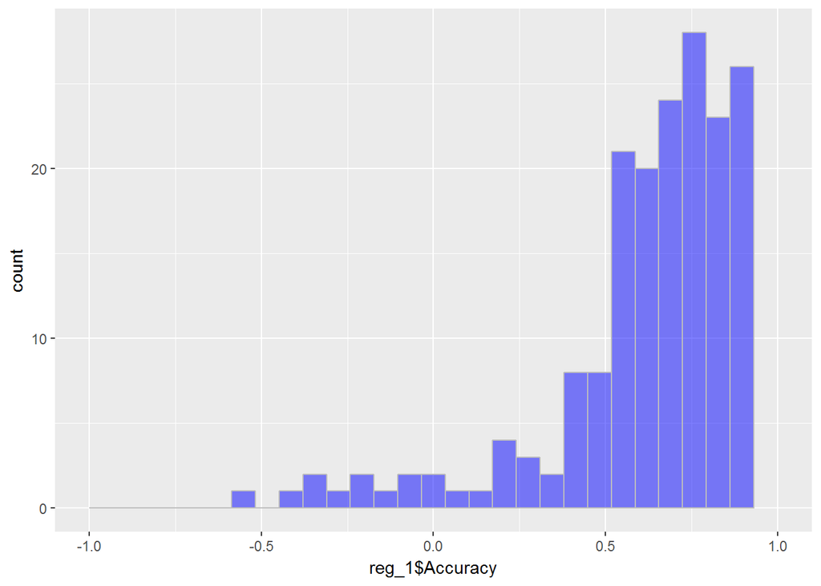

```r
#full model accuracy
reg_1$prediction<- predict(m3,reg_1)
reg_1$predicted_volume<- exp(reg_1$prediction)
reg_1$Accuracy <- 1-abs((reg_1$predicted_volume-reg_1$Unit_Sales)/reg_1$Unit_Sales)
qplot(reg_1$Accuracy, geom='histogram', fill=I("blue"), alpha=I(.5),col=I("grey"), xlim=c(-1,1))
```

The final check would just be a look at the accuracy distribution of the full model. Once again, we have around 50% of the records with >70% accuracy. Assuming we are confident with these final results, we get turn these model results into business insights.

Just to recap - the final model looks like this
$$log(Sales) = log(Price)+log(SI)+DiscountFlag$$

# Step 4: Model to Actionable Insights

In order to convert our model coefficients into something that is more useable to the business, we can generate a volume lift metric - a volume difference between a “baseline” (Our predicted volume based on the model, with all other factors held constant) and an “actual” (what actually happened) value.

Below is just one example of how lift can be calculated from a combination of our model coefficients, new data, and pre-defined “baseline” values for each variable. Baseline values can be set based on a combination of statistical analysis and business knowledge.

$$Y = int + B_1*X_1 + B_2*X_2 + B_3*X_3 + int$$
$$Y(baseline) = int + B_1*X1(baseline) + B2*X2(baseline) + B3*X3(baseline)$$

$$X_1 (Contribution) = [int + B_1*(X_1actual)+B2*(X_2baseline)+B3*(X_3baseline)] - Y(baseline)$$

$$X_1 (Lift) = X_1 (Contribution) - Y(baseline)$$